# High School Seniors t Test

.

```r
library(tidyverse)
library(DT)
library(pander)
library(readr)
library(mosaic)
library(car)

HSS <- read_csv("../../Data/HighSchoolSeniors.csv")
#Remember: select "Session, Set Working Directory, To Source File Location", and then play this R-chunk into your console to read the HSS data into R.
```

# Background

For this analysis I will be examining how much time those who play video games spend doing homework as well as examining how much time students that do play video games spend on homework. In particularly we’ll be testing to see if those who play video games spend less time doing homework then those who don’t play video games.

Our data frame will be the U.S. Census at School Questionnaire since it is a census of data on High School Seniors. In this analysis, the population I’ll be studying are the high school seniors at the schools participating in the U.S. Census at School Program.

# Analysis

The null hypothesis is that the difference of the population means for time spent doing homework by high school students who do and do not play video games is equal to 0. The alternative hypothesis is that the difference in means is less than 0. Alpha will equal .05.

$$H_0: \mu = \text{0}$$
$$H_a: \mu < \text{0}$$
$$\alpha = .05$$

### Clean the data frame

First, I’ll remove the entries that left the video game and/or homework sections blank. I’ll also need to remove any entries that report playing video games or doing homework for more than 168 hours a week since there are only 168 hours in a week.

I won’t remove the other sections just yet. Though, I can’t determine which entries were lies and which entries are actual errors based off of the responses recorded elsewhere on the survey, that information might help with detecting compromised entries in the video game and homework sections later on in the analysis.

```r
# filter out _ NA's, _ impossible values, and _1? entry that seemed to have been an error
# relevantdata0 <- HSS %>%
#   select(Gender,
#          Video_Games_Hours,
#          Doing_Homework_Hours,
#          Doing_Things_With_Family_Hours,
#          Sleep_Hours_Schoolnight,
#          Sleep_Hours_Non_Schoolnight,

relevantdata <- HSS %>%
  filter(!is.na(Video_Games_Hours),
         !is.na(Doing_Homework_Hours),
         Video_Games_Hours < 168,
         Doing_Homework_Hours < 168
         )
```

I’ll also check for any outliers that may have also been errors.

```r
outliers_games <- relevantdata %>%
  select(c(Video_Games_Hours, Doing_Homework_Hours)) %>%
  filter(Video_Games_Hours >=
           (sd(Video_Games_Hours)*3 + mean(Video_Games_Hours))
         ) %>%
  arrange(Video_Games_Hours,
          Doing_Homework_Hours) %>%
  droplevels()

outliers_hw <- relevantdata %>%
  select(c(Video_Games_Hours, Doing_Homework_Hours)) %>%
  filter(Doing_Homework_Hours >=
           (sd(Doing_Homework_Hours)*3 + mean(Doing_Homework_Hours))
         ) %>%
  arrange(Doing_Homework_Hours,
          Video_Games_Hours) %>%
  droplevels()
```

These are the outliers in the hours spent playing video games.

```r
#view(outliers_games %>% select(Video_Games_Hours))
datatable(outliers_games)
```

|  | Video_Games_Hours | Doing_Homework_Hours |
| --- | --- | --- |
| 1 | 48 | 0 |
| 2 | 50 | 0 |
| 3 | 50 | 12 |
| 4 | 50 | 40 |
| 5 | 55 | 4 |
| 6 | 56 | 2 |
| 7 | 70 | 3 |
| 8 | 70 | 4 |
| 9 | 94 | 20 |
| 10 | 100 | 100 |

These are the outliers in the hours spent doing homework.

```r
#view(outliers_hw %>% select(Doing_Homework_Hours))
datatable(outliers_hw)
```

|  | Video_Games_Hours | Doing_Homework_Hours |
| --- | --- | --- |
| 1 | 0 | 50 |
| 2 | 0 | 50 |
| 3 | 0.5 | 50 |
| 4 | 10 | 55 |
| 5 | 30 | 56 |
| 6 | 0 | 70 |
| 7 | 7 | 100 |
| 8 | 100 | 100 |

There are no other errors I can detect.

```r
relevantdata2 <-relevantdata %>%
  select(Video_Games_Hours,
         Doing_Homework_Hours,
         ) %>%
  filter(Video_Games_Hours != 100,
         Doing_Homework_Hours != 100)
```

### Group the data frame

Now we simply separate the data frame based on if they played video games or not. Anyone who reported playing video games for zero hours per week will be classified as a non-gamer, and anyone who reported playing video games for more than zero hours per week will be classified as a gamer.

```r
relevantdata2 <- relevantdata2 %>%
  mutate(gamer_status = ifelse(
    Video_Games_Hours == 0,
    "Non-gamer",
    "Gamer"
  ))

nongamers <- relevantdata2 %>%
  filter(Video_Games_Hours == 0)
gamers <- relevantdata2 %>%
  filter(Video_Games_Hours != 0)

relevantdata2 %>%
  group_by(gamer_status) %>%
  summarise(n = n()) %>%
  pander()
```

| gamer_status | n |
| --- | --- |
| Gamer | 254 |
| Non-gamer | 182 |

This gives us 254 gamers and 182 non-gamers to work with.

### Visualize the data

The distribution is visualized as follows:

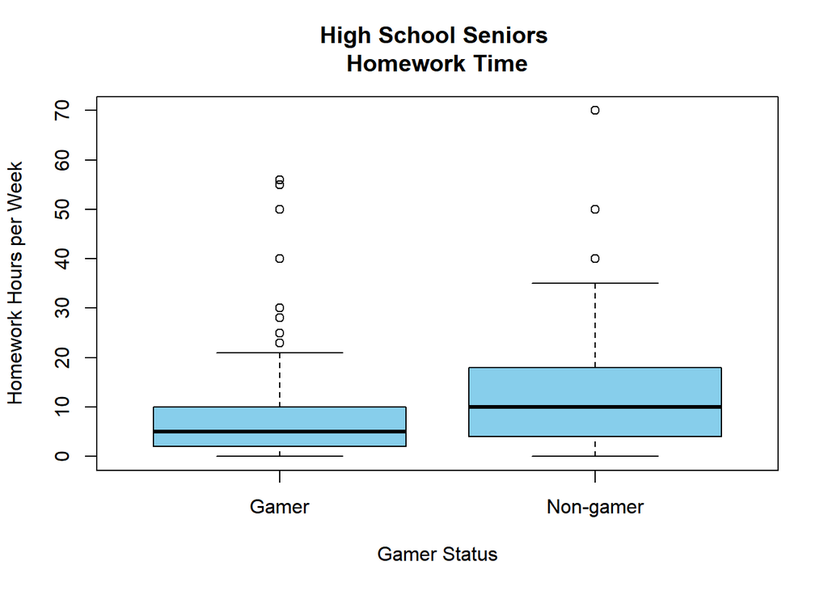

```r
boxplot(Doing_Homework_Hours ~ gamer_status,
        data = relevantdata2,
        main = 'High School Seniors \nHomework Time',
        xlab = 'Gamer Status',
        ylab = 'Homework Hours per Week',
        col = "skyblue"
        )
```

**Hours Spent Doing Homework Each Week**

```r
relevantdata2 %>%
  group_by(gamer_status) %>%
  summarise(Min = min(Doing_Homework_Hours),
            Q1 = quantile(Doing_Homework_Hours, .25),
            Mean = mean(Doing_Homework_Hours),
            Med = median(Doing_Homework_Hours),
            Q3 = quantile(Doing_Homework_Hours, .75),
            Max = max(Doing_Homework_Hours),
            SD = sd(Doing_Homework_Hours),
            n = n()
  ) %>%
  pander()
```

| gamer_status | Min | Q1 | Mean | Med | Q3 | Max | SD | n |
| --- | --- | --- | --- | --- | --- | --- | --- | --- |
| Gamer | 0 | 2 | 8.441 | 5 | 10 | 56 | 9.571 | 254 |
| Non-gamer | 0 | 4 | 12.33 | 10 | 18 | 70 | 11.5 | 182 |

### Independent Samples t Test requirements

Though this data frame was gathered via a high school survey, the data frame is identified as a census and so I must assume that both samples are representative of the population. Remember, the population is the high school seniors at the U.S. schools participating in the Census at School Program.

Now we must determine if the data has a normal distribution.

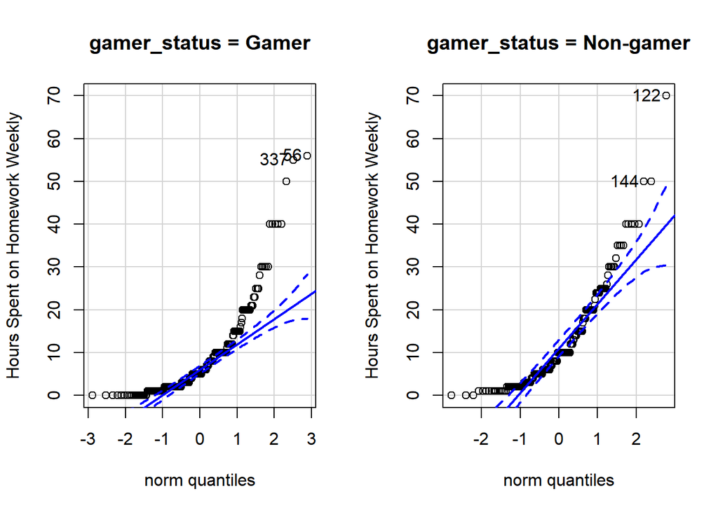

```r
qqPlot(Doing_Homework_Hours ~ gamer_status,
       data = relevantdata2,
       ylab = "Hours Spent on Homework Weekly"
       )
```

We can see that the data does not fall as normal within a Q-Q plot.

However, since the samples size are sufficiently large (greater than 30), the sampling distribution of the difference of the sample means (x¯1−x¯2) can be assumed to be normal.

Thus, though the data is highly skewed, the requirements for an Independent Samples t Test requirement have been met and a t-test can be performed.

### Independent Samples t-Test

The independent two samples t-test yields the following information:

```r
t.test(gamers$Doing_Homework_Hours,
       nongamers$Doing_Homework_Hours,
       mu = 0,
       alternative = "less",
       conf.level = 0.95
       ) %>%
  pander()
```

Welch Two Sample t-test: `gamers$Doing_Homework_Hours` and `nongamers$Doing_Homework_Hours` (continued below)

| Test statistic | df | P value | Alternative hypothesis | mean of x |
| --- | --- | --- | --- | --- |
| -3.731 | 344.5 | 0.0001113 * * * | less | 8.441 |

| mean of y |
| --- |
| 12.33 |

Since our p-value is 0.0001113, and our alpha is .05, there is sufficient evidence to reject the null hypothesis.

# Interpretation

We accept the alternative hypothesis that High School Students who play video games spend less time doing homework than the students who don’t play video games.

# Conclusion

According to this t-test there is strong evidence that the alternative hypothesis can be accepted. Had our alpha been .01, .001, or even .00012, the null hypothesis would still have been rejected.

That being said, we’d need to analyze more of this data to find out what the effects of spending less time doing homework had on the High School Senior Gamer population. In this census those that played video games studied homework, on average, for about 3.889 hours less than their non-gamer counterparts. Weather the gamer population had lower grades than the non-gamer population is unknown, however, and we also don’t know just yet were those four hours were spent.